### Sentiment Analysis - Kimono + MonkeyLearn

Hossein Parsa

#### Introduction

Customers reviews of products and services are a great source of feedback and to a large extent can enable businesses and service providers to improve their service and align that with the customers need. One way of gathering this data is web scraping. New tool have recently emerged to enable data scraping and convert the collection of this set of data into meaningful information.

Two of the tools that we will be working with in this article are [Kimono](https://www.kimonolabs.com) for scraping the web data and [MonkeyLearn](http://monkeylearn.com) that provided machine learning feature. The cooperation of these tool can interpret customer review into helpful insight about the business.

Our objective is to create a tool that measures the expressed sentiments in user book and restaurant review.

#### Kimono

Kimono is an intelligent tool that turn websites into structures APIs. It makes the user is capable of building an API without writing any specific code to scrape the web and navigate html codes. Its smart extractor recognizes patterns in the web content allowing to get the data easily and classify text information.

For this analysis we consider reviews of users for Club A Steakhouse restaurant in New York City. This includes the body of the reviews and the star rates given by reviewer. To collect the review data we will visit TripAdvisor website, webpage of [Club A Steakhouse](http://www.tripadvisor.com/Restaurant_Review-g60763-d1236281-Reviews-Club_A_Steakhouse-New_York_City_New_York.html). For that purpose, we need to create an API using Kimono to crawl reviews. A sample review is shown in the figure below.

[figure not shown]

To create this API we visit the review page of the restaurant on Google Chrome and activate Kimono extension. Once Kimono is activated we select a body of a review paragraph and name the property as body and then add another property and call it stars and select the star ratings. the selected properties will look like the figure below.

[figure not shown]

on the “Data Model Review” page and on the advanced setting, we need make sure that the “alt” attribute for stars property is selected so that we are able to extract the number of stars.

[figure not shown]

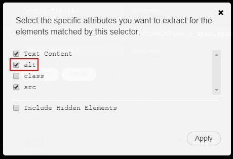

Now we can save the API and start crawling. For this API we did not consider pagination because most of the time that we tried, Kimono pagination did not work properly and cause the crawling to fail returning most of the pages. Instead, we will manually create the list of review pages based on the pattern. It can be simply done by concatenation the first part of the URL, a sequence with step 10, and the second part of the URL. Then in the crawl setup tab we will be setting the crawl strategy to generated URL list. In the URL generator section of the tab we will select custom list from the drop down and insert the generated URLs. Each URL will return 10 records so the total records returned by this API will be 1010.

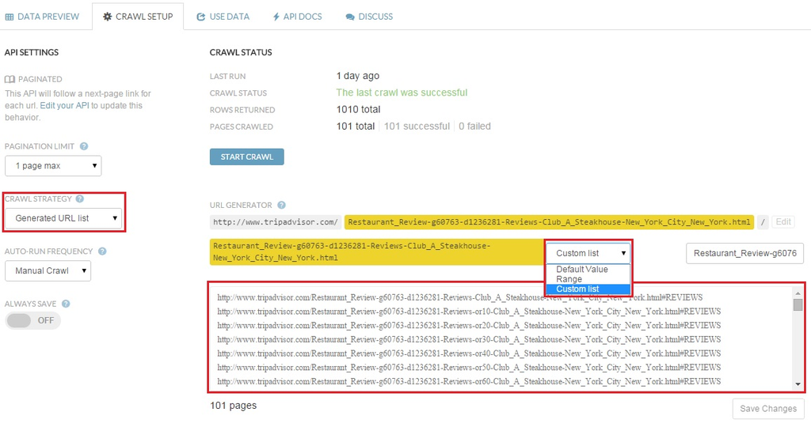

Once the crawling is finished the returned data are available to download in CSV, RSS and JSON.

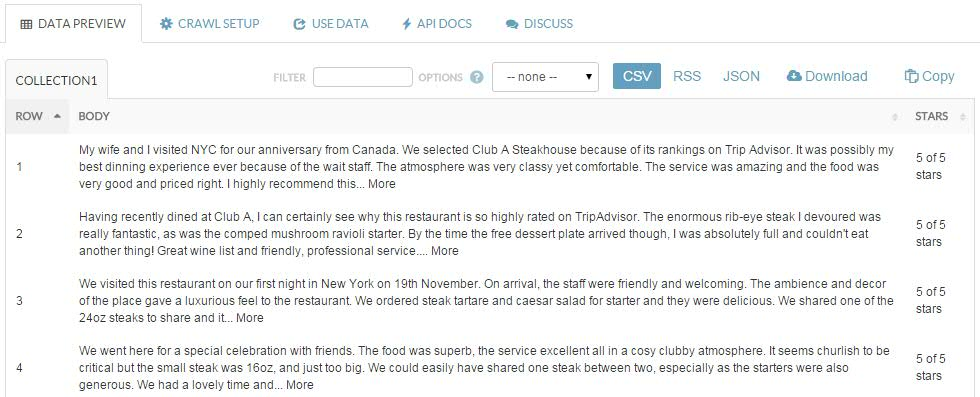

To get the downloaded data prepared for machine learning using MonkeyLearn we apply some data cleaning transformation to the text data shown in the `R` code below; for this purpose we use `stringi` package.

```r
library(stringi)

dataraw<-read.csv("tripadvisor_clubasteakhouse_1000_kimonoData.csv", header=F, skip=1, sep=",", na.string="")
data<-dataraw
names(data)<-c("review", "stars")
data<-subset(data, !is.na(review) & !is.na(stars))
data$review<-stri_replace_all_charclass(data$review, "\\p{WHITE_SPACE}", " ", merge=T)
data$review<-stri_replace_all_charclass(data$review, "[[:punct:]]", " ", merge=T)
data$review<-stri_replace_all_regex(data$review, "([[:alpha:]])\\1{2,}+", "$1")
data$review<-stri_replace_all_regex(data$review, "[^[:alnum:]]", " ", merge=T)
data$review<-stri_replace_all_regex(data$review, "\\p{Z}{1,}+", " ")
data$stars<-stri_replace_all_fixed(data$stars, "of 5 stars", "")
data$stars<-stri_replace_all_regex(data$stars, "4|5", "positive")
data$stars<-stri_replace_all_regex(data$stars, "1|2|3", "non_positive")
data<-unique(data)

write.table(data, "RRA_clubasteakhouse.csv", sep=",", row.names=F, col.names=F, append=F)
```

In the above code we remove line breaks, punctuation, two or more blanks and we get only alphanumeric values. More importantly we convert star rates of 4 or 5 to positive and 1, 2 or 3 to non-positive. Hence these are the tags we will use for classification of the reviews.

#### MonkeyLearn

We start by creating a module and naming it Restaurant Review Analysis with a short description in the Settings tab, basic settings. In the Advanced setting we check normalized weights, use stemming and filter stopwords. We also select unigrams, bigrams and trigrams for the N-gram range and leave the Max features to its default value.

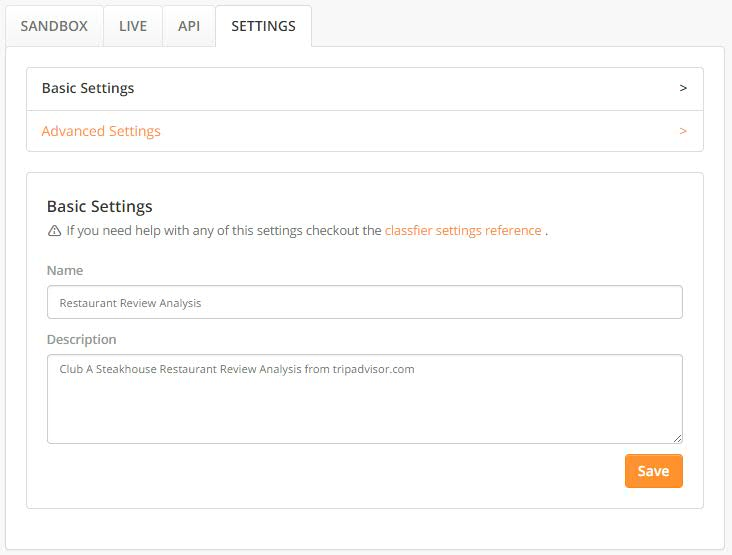

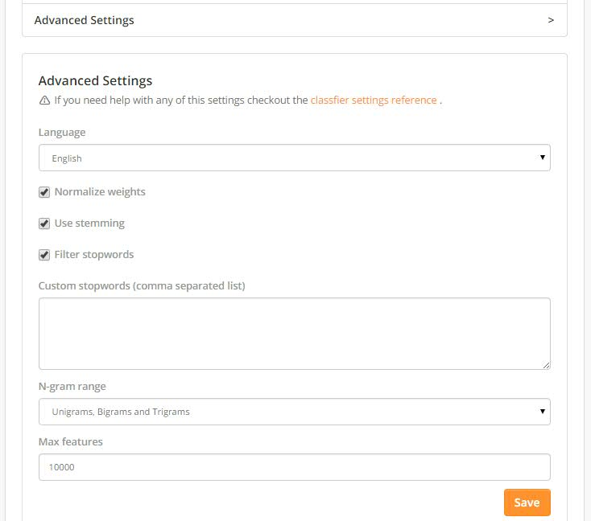

Then we will upload the file that we created in the previous step to train the data.

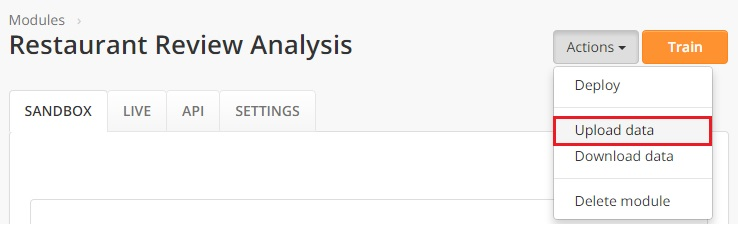

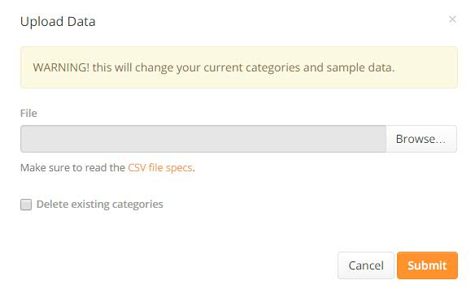

By training the data the category tree will be shown with the classes. The statistics are also provided at the root as well as class levels. The statistics include accuracy, number of samples, confusion matrix and also keyword list. A wordcloud is also depicted based on the keyword list.

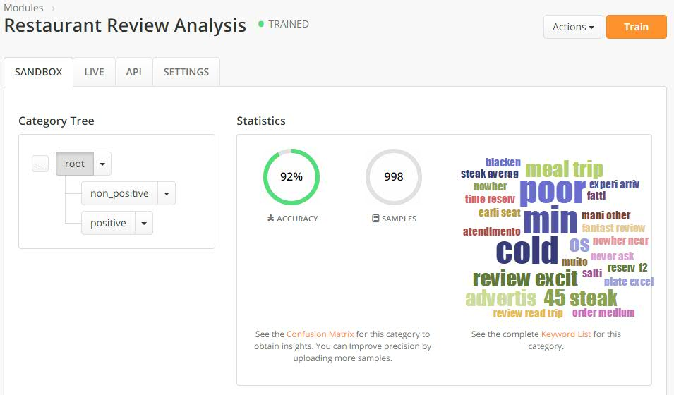

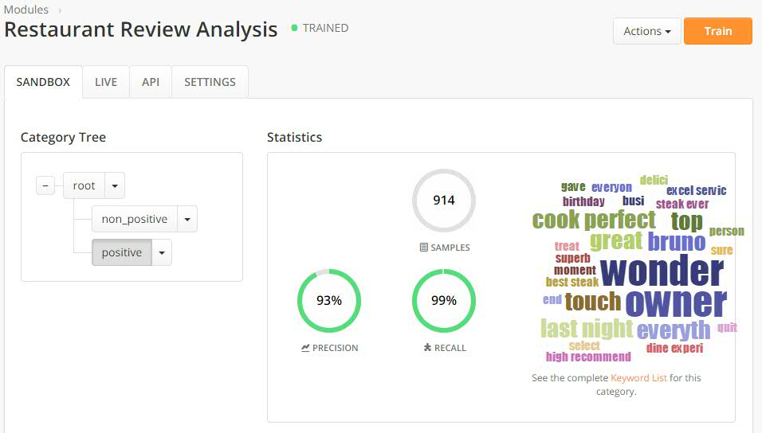

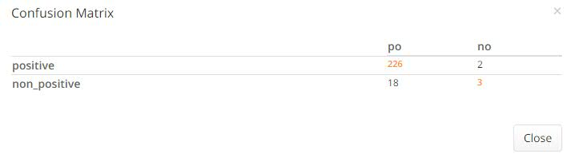

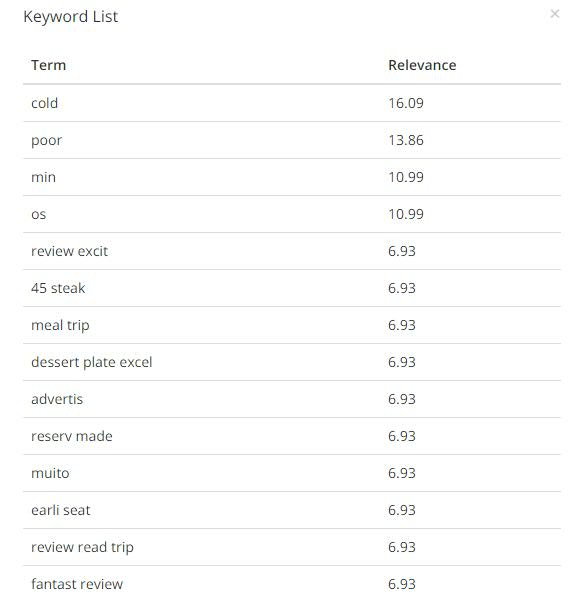

Once the training is complete, New reviews can be classified in the API tab. by entering a new review and submit it, the classification is shown with a probability in json format.

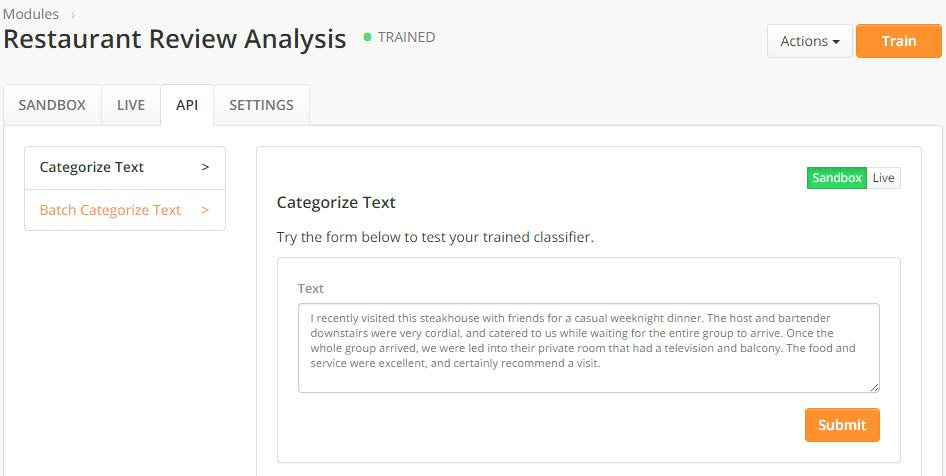

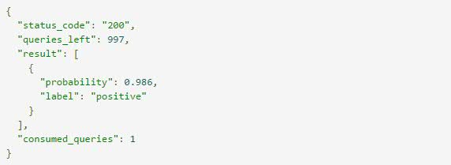

In the above example the test review is classified as positive with the probability of 0.986.